# Jahresbilanz der Schweizer Gletscher

- Gesamten Code zeigen
- Gesamten Code verbergen
- Quellcode anzeigen

Arbeitsblatt 2, zweiter Datensatz – Principles of Data Visualization, Herbstsemester 2026

Autor:in

Elio Schmid

Veröffentlichungsdatum

19.10.2026

Geändert

20.10.2026

**Code anzeigen**

```r
library(tidyverse)
theme_set(theme_minimal(base_size = 12))

pfad      <- "massbalance_fixdate.csv"                      # Gletscherwerte pro Hydrojahr
pfad_hoehe <- "massbalance_observation_elevationbins.csv"   # Höhenstufen (nur Ansatz 5)
```

**Autor:** Elio Schmid, FH Graubünden, MSc Data Visualization  
**Dozentin:** PD Dr. rer. nat. Helena Jambor  
**Ort, Datum:** Bern, 19.10.2026

**Hinweis**

Dieses Dokument ist in Bearbeitung und wird laufend ergänzt. Das Datum der letzten Änderung steht im Titelblock oben.

# 1 Erster Datensatz: Volumenänderung

Anfang Oktober habe ich einen Artikel von SRF über den Gletscherschwund in der Schweiz gelesen. Der Artikel ist hier [verlinkt.](https://www.srf.ch/wissen/klimawandel/eisverlust-2026-massive-gletscherschmelze-so-viel-eis-verschwand-im-hitzesommer) Darin wird auf Daten von Glamos - Glacier Monitoring in Switzerland verwiesen. Das Thema interessiert mich insofern, als dass ich relativ viel in den Bergen unterwegs bin. Auf der Website von Glamos finden wir Daten zu Bestand, Längenänderung, Massenbilanz, Volumenänderung sowie Szenarien. Die Daten unterscheiden sich in Stichtagsmessungen und Zeitreihen. Es werden Flächen-, Ausdehnungs- und Geodaten erfasst. In meiner Analyse möchte ich mich auf die Volumenänderung konzentrieren. Ich kann mir aber vorstellen auch Bestandesdaten einfliessen zu lassen oder Längenänderungen. Dies werde ich im Zuge der Auswertung wohl feststellen. Der Datensatz, den ich analysieren möchte, lässt sich [hier](https://doi.glamos.ch/data/volumechange/volumechange_2025_r2025.html) einsehen.

Nach der ersten Auseinandersetzung mit dem Datensatz, muss ich festhalten, dass es doch schwerer ist diesen auszuwerten als vorerst angenommen. Die Beobachtungszeiträume überschneiden sich und Aussagen zu Entwicklungen über eine Zeitdistanz sind anspruchsvoll. Sie können höchstens für einen gewissen Teil der Gletscher erfolgen.Aus diesem Grund starte ich einen zweiten Versuch mit den Daten der Gletschermassenbilanz (hydrologisches Jahr). Ich erhoffe mir davon bessere Möglichkeiten für Auswertungen über die Zeit, weil die Messungen jährlich erfolgen und sich nicht überlappen.Auch der Upload in Datawrapper hat mir gleich gezeigt, dass Auswertungen über die Zeit mit diesem Datensatz “einfacher” zu realisieren sind.

# 2 Zweiter Datensatz: Massenbilanz pro Hydrojahr

## 2.1 Datensatz

Auch dieser Datensatz ist bei GLAMOS verfügbar.Eine Zeile beschreibt **einen Gletscher in einem Hydrojahr** (jeweils von Oktober bis September). Die Winterbilanz (Bw) ist der Zugewinn durch Schnee bis Ende April, die Sommerbilanz (Bs) der Verlust danach, die Jahresbilanz (Ba) die Summe der beiden. Eine Bilanz von −1000 mm w.e. bedeutet, dass der Gletscher im Mittel über seine Fläche eine Wasserschicht von 1 m verloren hat. Zusätzlich gibt es die Gleichgewichtslinie (ELA), also die Höhe, oberhalb der im Jahr netto Masse zugewinnt, und den Anteil der Fläche oberhalb dieser Linie (AAR).

**Code anzeigen**

```r
tibble(
  Variable = c("glacier_name", "glacier_id", "date_start", "date_end_winter",
               "date_end", "Bw", "Bs", "Ba", "ELA", "AAR", "area_km2",
               "h_min", "h_max", "observer"),
  Bedeutung = c("Name des Gletschers",
                "ID gemäss Swiss Glacier Inventory",
                "Beginn des Hydrojahres",
                "Ende der Winterbeobachtung",
                "Ende des Hydrojahres",
                "Winterbilanz (Gletschermittel)",
                "Sommerbilanz (Gletschermittel)",
                "Jahresbilanz (Bw + Bs)",
                "Höhe der Gleichgewichtslinie",
                "Anteil der Fläche oberhalb der Gleichgewichtslinie",
                "Gletscherfläche im Jahr",
                "Tiefster Punkt des Gletschers",
                "Höchster Punkt des Gletschers",
                "Datenquelle bzw. Referenz"),
  Einheit = c("–", "–", "yyyy-mm-dd", "yyyy-mm-dd", "yyyy-mm-dd",
              "mm w.e.", "mm w.e.", "mm w.e.", "m ü. M.", "%", "km²",
              "m ü. M.", "m ü. M.", "–")
) |>
  knitr::kable()
```

| Variable | Bedeutung | Einheit |
| --- | --- | --- |
| glacier_name | Name des Gletschers | – |
| glacier_id | ID gemäss Swiss Glacier Inventory | – |
| date_start | Beginn des Hydrojahres | yyyy-mm-dd |
| date_end_winter | Ende der Winterbeobachtung | yyyy-mm-dd |
| date_end | Ende des Hydrojahres | yyyy-mm-dd |
| Bw | Winterbilanz (Gletschermittel) | mm w.e. |
| Bs | Sommerbilanz (Gletschermittel) | mm w.e. |
| Ba | Jahresbilanz (Bw + Bs) | mm w.e. |
| ELA | Höhe der Gleichgewichtslinie | m ü. M. |
| AAR | Anteil der Fläche oberhalb der Gleichgewichtslinie | % |
| area_km2 | Gletscherfläche im Jahr | km² |
| h_min | Tiefster Punkt des Gletschers | m ü. M. |
| h_max | Höchster Punkt des Gletschers | m ü. M. |
| observer | Datenquelle bzw. Referenz | – |

## 2.2 Daten einlesen

**Abschnitt anzeigen**

Die Datei hat 9 Kopfzeilen (Lizenz, Titel, ausführliche Namen, Kurznamen, Einheiten), die Daten beginnen in Zeile 10. Die Spalte `observer` enthält teils Kommas (z. B. «GLAMOS (2025), Huss 2015 (…)»). Deshalb lese ich jede Zeile als Text ein und trenne nur nach den ersten 13 Kommas, den Rest behalte ich als Quelle.

**Code anzeigen**

```r
zeilen <- read_lines(pfad)[-(1:9)]
zeilen <- zeilen[zeilen != ""]

spalten <- c("glacier_name", "glacier_id", "date_start", "date_end_winter",
             "date_end", "Bw", "Bs", "Ba", "ELA", "AAR", "area_km2",
             "h_min", "h_max", "observer")

roh <- tibble(zeile = zeilen) |>
  separate(zeile, into = spalten, sep = ",", extra = "merge", fill = "right") |>
  mutate(across(everything(), str_trim))

glimpse(roh)
```

```
Rows: 1,239
Columns: 14
$ glacier_name    <chr> "Silvrettagletscher", "Silvrettagletscher", "Silvretta…
$ glacier_id      <chr> "A10g-05", "A10g-05", "A10g-05", "A10g-05", "A10g-05",…
$ date_start      <chr> "1914-10-01", "1915-10-01", "1916-10-01", "1917-10-01"…
$ date_end_winter <chr> "1915-04-30", "1916-04-30", "1917-04-30", "1918-04-30"…
$ date_end        <chr> "1915-09-30", "1916-09-30", "1917-09-30", "1918-09-30"…
$ Bw              <chr> "1503", "1415", "1872", "1075", "1862", "2467", "815",…
$ Bs              <chr> "-1918", "-1034", "-1900", "-1489", "-840", "-1884", "…
$ Ba              <chr> "-415", "381", "-28", "-414", "1022", "583", "-2546", …
$ ELA             <chr> "2795", "2625", "2725", "2805", "2445", "2635", "3151"…
$ AAR             <chr> "45", "75", "60", "42", "98", "77", "0", "78", "80", "…
$ area_km2        <chr> "4.06687", "3.55563", "3.55563", "3.55563", "3.55563",…
$ h_min           <chr> "2406", "2414", "2414", "2414", "2414", "2414", "2414"…
$ h_max           <chr> "3185", "3091", "3091", "3091", "3091", "3091", "3091"…
$ observer        <chr> "GLAMOS (2025), Huss 2015 (https://doi.org/10.3189/201…
```

## 2.3 Bereinigung

**Abschnitt anzeigen**

Die Daten sind bereits sauber: keine fehlenden Werte, ISO-Datum, keine Platzhalter. Es sind nur noch wenige Schritte nötig: Typen setzen, das Jahr (Jahr des Periodenendes) und die Dauer berechnen und die Bilanzen in m w.e. umrechnen, damit sie sich besser lesen lassen.

**Code anzeigen**

```r
gl <- roh |>
  mutate(
    across(c(Bw, Bs, Ba, ELA, AAR, area_km2, h_min, h_max), as.numeric),
    across(c(date_start, date_end_winter, date_end), as.Date),
    jahr       = year(date_end),
    dauer_tage = as.numeric(date_end - date_start),
    # Bilanzen in m w.e. (anschaulicher als mm)
    Bw_m = Bw / 1000,
    Bs_m = Bs / 1000,
    Ba_m = Ba / 1000,
    # ELA nicht beobachtbar, wenn der Gletscher gar kein Nährgebiet hat
    # oder die Linie über dem höchsten Punkt liegt: extrapolierter Wert
    ela_extrapoliert = AAR == 0 | ELA > h_max
  ) |>
  select(-Bw, -Bs, -Ba)
```

## 2.4 Datenqualität

**Abschnitt anzeigen**

**Code anzeigen**

```r
# Fehlende Werte
gl |> summarise(across(everything(), ~ sum(is.na(.x)))) |>
  pivot_longer(everything(), names_to = "variable", values_to = "n_na") |>
  filter(n_na > 0)
```

```
# A tibble: 0 × 2
# ℹ 2 variables: variable <chr>, n_na <int>
```

**Code anzeigen**

```r
# Mehrere Zeilen pro Gletscher und Jahr?
gl |> count(glacier_id, jahr) |> filter(n > 1)
```

```
# A tibble: 0 × 3
# ℹ 3 variables: glacier_id <chr>, jahr <dbl>, n <int>
```

**Code anzeigen**

```r
# Länge der Hydrojahre
summary(gl$dauer_tage)
```

```
   Min. 1st Qu.  Median    Mean 3rd Qu.    Max.
  364.0   364.0   364.0   364.3   365.0   365.0
```

**Code anzeigen**

```r
# Bilanz = Winter + Sommer?
sum(abs(gl$Ba_m - (gl$Bw_m + gl$Bs_m)) > 0.001)
```

```
[1] 0
```

**Code anzeigen**

```r
# ELA als extrapolierter Wert
gl |> summarise(aar_null = sum(AAR == 0), ela_ueber_gipfel = sum(ELA > h_max),
                extrapoliert = sum(ela_extrapoliert))
```

```
# A tibble: 1 × 3
  aar_null ela_ueber_gipfel extrapoliert
     <int>            <int>        <int>
1      117              153          163
```

**Code anzeigen**

```r
# Herkunft der Daten
gl |> count(observer, sort = TRUE) |> head(6)
```

```
# A tibble: 6 × 2
  observer                                                                  n
  <chr>                                                                 <int>
1 GLAMOS (2025), Huss 2015 (https://doi.org/10.3189/2015JoG15J015)        730
2 VAW / ETH Zuerich, Huss et al. 2015, Journal.of Glaciology              226
3 GLAMOS (2025)                                                            88
4 GLAMOS (2025), Fischer 2016 (https://doi.org/10.5194/tc-10-1279-2016)    40
5 VAW / ETH Zuerich, O  Langenegger, unpublished                           35
6 GLAMOS (2025), Zekollari 2018 (https://doi.org/10.1017/jog.2018.18)      24
```

Die Beobachtungen dazu:

- Es gibt keine fehlenden Werte und pro Gletscher und Jahr genau eine Zeile. Alle Hydrojahre dauern 364 oder 365 Tage. Die fünf auffälligen Gletscherjahre aus der Höhenstufen-Version (5 Tage, −14 Tage, 732 Tage, 291 und 297 Tage) kommen hier nicht vor. Der einzige Unterschied bei den Gletscherjahren ist eine zusätzliche Zeile (Ofentalgletscher 1965).
- ELA und AAR sind nicht immer gemessene Werte. Bei 117 Gletscherjahren ist die AAR 0 (kein Nährgebiet), bei insgesamt 163 liegt die ELA über dem höchsten Punkt des Gletschers oder die AAR ist 0. Diese ELA-Werte sind extrapoliert und werden in den Grafiken getrennt markiert. 2022 betrifft das 22 von 28 Gletschern.
- Die Spalte `observer` ist hier die Datenquelle. Bei 956 von 1’239 Zeilen wird Huss et al. 2015 genannt (in zwei Schreibweisen), eine Studie, die für viele Gletscher die Reihen rekonstruiert hat. Die Werte sind also nicht alle direkte Messungen, und die Quelle ist ein Hinweis auf unterschiedliche Datenqualität.

## 2.5 Basiskennzahlen

**Abschnitt anzeigen**

**Code anzeigen**

```r
tibble(
  anzahl_zeilen    = nrow(gl),
  anzahl_gletscher = n_distinct(gl$glacier_id),
  jahr_von         = min(gl$jahr),
  jahr_bis         = max(gl$jahr),
  median_Ba_m      = median(gl$Ba_m),
  anteil_negativ   = mean(gl$Ba_m < 0)
)
```

```
# A tibble: 1 × 6
  anzahl_zeilen anzahl_gletscher jahr_von jahr_bis median_Ba_m anteil_negativ
          <int>            <int>    <dbl>    <dbl>       <dbl>          <dbl>
1          1239               43     1885     2025      -0.559          0.748
```

**Code anzeigen**

```r
# Zeitliche Abdeckung pro Gletscher
abdeckung <- gl |>
  group_by(glacier_name) |>
  summarise(von = min(jahr), bis = max(jahr), n_jahre = n(),
            groesste_luecke = max(c(1, diff(sort(jahr)))), .groups = "drop") |>
  arrange(desc(n_jahre))

head(abdeckung, 12)
```

```
# A tibble: 12 × 5
   glacier_name               von   bis n_jahre groesste_luecke
   <chr>                    <dbl> <dbl>   <int>           <dbl>
 1 Grosser Aletschgletscher  1915  2025     111               1
 2 Silvrettagletscher        1915  2025     111               1
 3 Claridenfirn              1915  2025     109               3
 4 Allalingletscher          1956  2025      70               1
 5 Hohlaubgletscher          1956  2025      70               1
 6 Schwarzberggletscher      1956  2025      70               1
 7 Griesgletscher            1962  2025      64               1
 8 Glacier du Giétro         1967  2025      59               1
 9 Rhonegletscher            1885  2025      44              98
10 Tällibodengletscher       1956  1996      41               1
11 Chessjengletscher         1956  1995      40               1
12 Limmerngletscher          1948  1985      38               1
```

**Code anzeigen**

```r
# Anzahl Gletscher mit Messwert pro Jahr
gl |> count(jahr) |>
  filter(jahr %in% c(1920, 1940, 1960, 1980, 2000, 2010, 2020, 2025))
```

```
# A tibble: 8 × 2
   jahr     n
  <dbl> <int>
1  1920     3
2  1940     3
3  1960    13
4  1980    12
5  2000    10
6  2010    19
7  2020    30
8  2025    27
```

## 2.6 Erste Übersicht

**Abschnitt anzeigen**

**Code anzeigen**

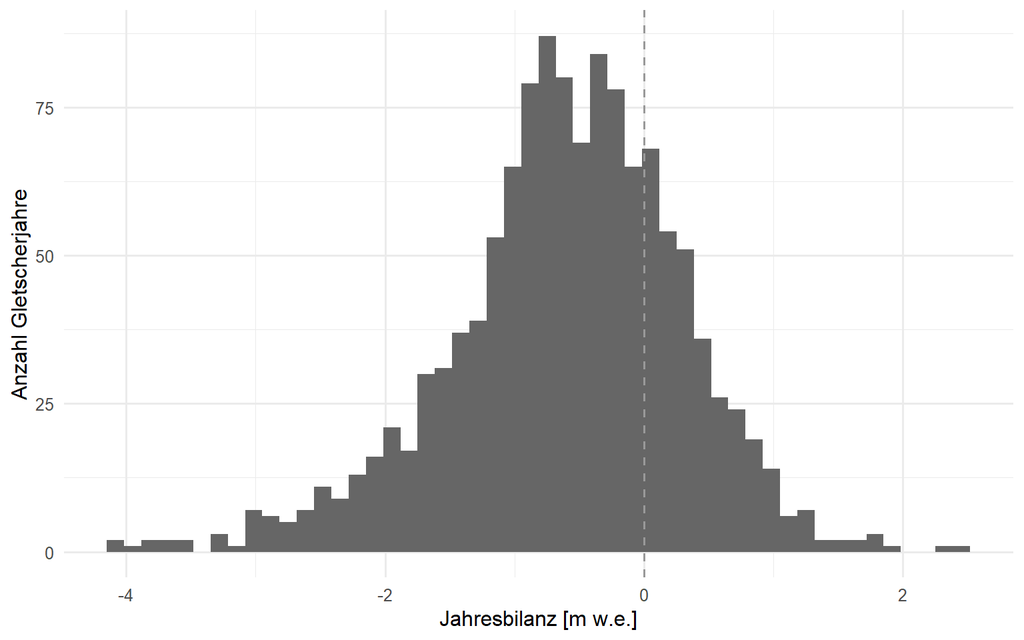

Abbildung 1: Verteilung der Jahresbilanz pro Gletscher und Jahr

```r
ggplot(gl, aes(Ba_m)) +
  geom_histogram(bins = 50, fill = "grey40") +
  geom_vline(xintercept = 0, linetype = "dashed", colour = "grey60") +
  labs(x = "Jahresbilanz [m w.e.]", y = "Anzahl Gletscherjahre")
```

**Code anzeigen**

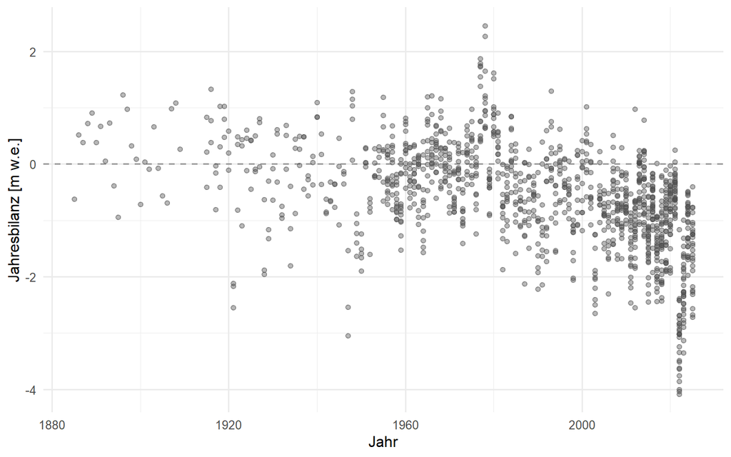

Abbildung 2: Erste Übersicht: Jahresbilanz aller Gletscherjahre über die Zeit

```r
ggplot(gl, aes(jahr, Ba_m)) +
  geom_hline(yintercept = 0, linetype = "dashed", colour = "grey60") +
  geom_point(alpha = 0.4, colour = "grey30") +
  labs(x = "Jahr", y = "Jahresbilanz [m w.e.]")
```

## 2.7 Welche Fragestellungen möchte ich mit diesem Datensatz beantworten?

Bereits bei meinem ersten Versuch wollte ich eine Entwicklung über die Zeit darstellen.Das möchte ich nun auch mit diesem Datensatz versuchen. Zudem können wir einzelne Gletscher aus unterschiedlichen Regionen der Schweiz vergleichen. Wenn möglich, möchte ich Zusammenhänge von z.B. der Höhe und der Entwicklung der Massenbilanz darstellen.

## 2.8 Visualisierungsansätze

Nachfolgend erste Visualisierungsansätze. Der Datensatz beinhaltet insgesamt 9 Gletscher, die eine fast lückenlose Messreihe ab 1990 aufweisen. Diese werden für eine Aussage über die Zeit verwendet.Bei den nachfolgenden Visualisierungen handelt es sich um erste Würfe. Farbliche Ausgestaltung und ergänzende Texte werden noch vertiefter bearbeitet

**Code anzeigen**

```r
# Gletscher mit (fast) lückenloser Reihe ab 1990: konstantes Sample für Zeitvergleiche
konstant <- gl |>
  filter(jahr >= 1990) |>
  count(glacier_id, glacier_name) |>
  filter(n >= 34)

konstant$glacier_name
```

```
[1] "Silvrettagletscher"       "Claridenfirn"
[3] "Grosser Aletschgletscher" "Griesgletscher"
[5] "Schwarzberggletscher"     "Allalingletscher"
[7] "Hohlaubgletscher"         "Glacier du Giétro"
[9] "Ghiacciaio del Basòdino"
```

**Code anzeigen**

```r
reihe_konstant <- gl |>
  filter(glacier_id %in% konstant$glacier_id, jahr >= 1990) |>
  group_by(jahr) |>
  summarise(n = n(), Bw = mean(Bw_m), Bs = mean(Bs_m), Ba = mean(Ba_m),
            ELA = mean(ELA), AAR = mean(AAR), .groups = "drop")
```

### 2.8.1 Ansatz 1: Heatmap aller Gletscher über die Zeit

**Frage:** Welche Gletscher wurden wann gemessen, und welche Jahre waren für alle Gletscher gleichzeitig extrem?

**Aufbau der Visualisierung:** Muster über Gletscher und Zeit erkennen, Datenlücken sichtbar machen. Rechtecke in einem Raster. Die x-Achse zeigt das Jahr, die y-Achse den Gletscher (sortiert nach dem ersten Messjahr), die Farbe die Jahresbilanz auf einer divergierenden Skala mit Mitte bei null. Weisse Felder bedeuten, dass kein Wert vorliegt. So sehen wir Datenlücken und Werte in derselben Grafik.

**Code anzeigen**

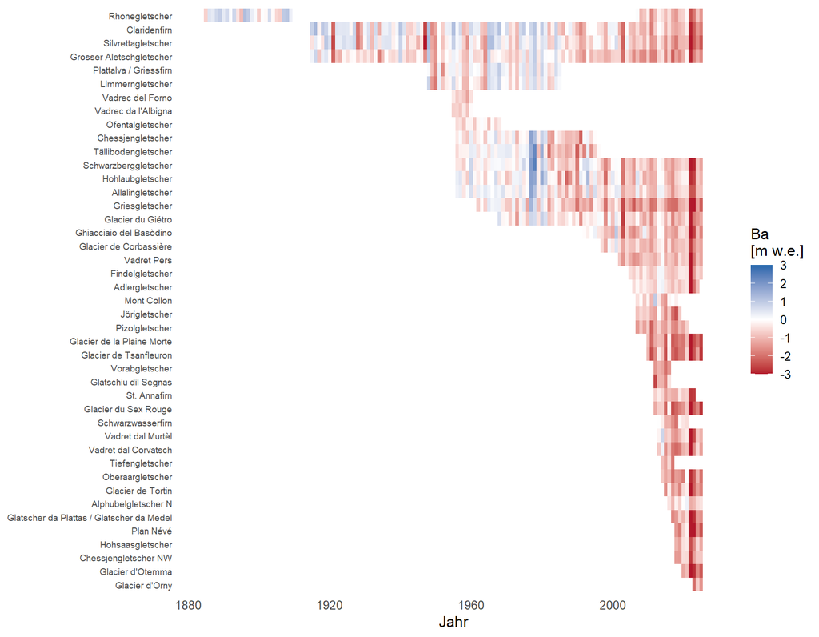

```r
reihenfolge <- gl |>
  group_by(glacier_name) |>
  summarise(erster = min(jahr), n = n(), .groups = "drop") |>
  arrange(desc(erster), desc(n))

gl |>
  mutate(glacier_name = factor(glacier_name, levels = reihenfolge$glacier_name)) |>
  ggplot(aes(jahr, glacier_name, fill = Ba_m)) +
  geom_tile() +
  scale_fill_gradient2(low = "#b2182b", mid = "white", high = "#2166ac",
                       midpoint = 0, limits = c(-3, 3), oob = scales::squish) +
  labs(x = "Jahr", y = NULL, fill = "Ba\n[m w.e.]") +
  theme(panel.grid = element_blank(), axis.text.y = element_text(size = 7))
```

**Erkenntnis:** Aus der Heatmap können mehrere Informationen gleichzeitig ausgelesen werden. Erstens zeigt sie die Datenlage: Drei Gletscher (Silvretta, Aletsch, Claridenfirn) wurden seit 1915 gemessen, eine grössere Gruppe ab Mitte der 1950er-Jahre, die meisten anderen erst seit etwa 2010. Der Rhonegletscher hat zwei getrennte Blöcke (1885 bis 1909 und ab 2007). Zweitens sieht man, dass einzelne Jahre bei fast allen Gletschern gleichzeitig dunkelrot sind (2022, 2003), während die Blautöne der 1960er- und 1970er-Jahre in den letzten Jahrzehnten fast verschwunden sind.In dieser Version müssen die fehlenden Werte farblich noch überarbeitet werden. Die Unterscheidung zwischen einer neutralen Massenbilanz (0 Wert) und einem fehlenden Wert ist schwer zu machen.Überprüft wird zudem ob die Skala passend ist.

### 2.8.2 Ansatz 2: Jahresbilanz im Zeitverlauf mit konstantem Sample

**Frage:** Wie hat sich die Jahresbilanz verschiedener Schweizer Gletscher seit 1990 entwickelt?

**Aufbau der Visualisierung:** Für den Vergleich über die Zeit ist ein Liniendiagramm sinnvoll. Die Zeit liegt auf der x-Achse, die Jahresbilanz auf der y-Achse Die dünnen grauen Linien sind die einzelnen Gletscher, die dicke schwarze Linie ist der Mittelwert über die 9 zuvor genannten Gletscher, die in praktisch allen Jahren seit 1990 gemessen wurden. Die Linien bilden dadurch die echte Veränderung ab und nicht eine Veränderung die ensteht wegen der Veränderung der Anzahl gemessenen Gletscher.

**Code anzeigen**

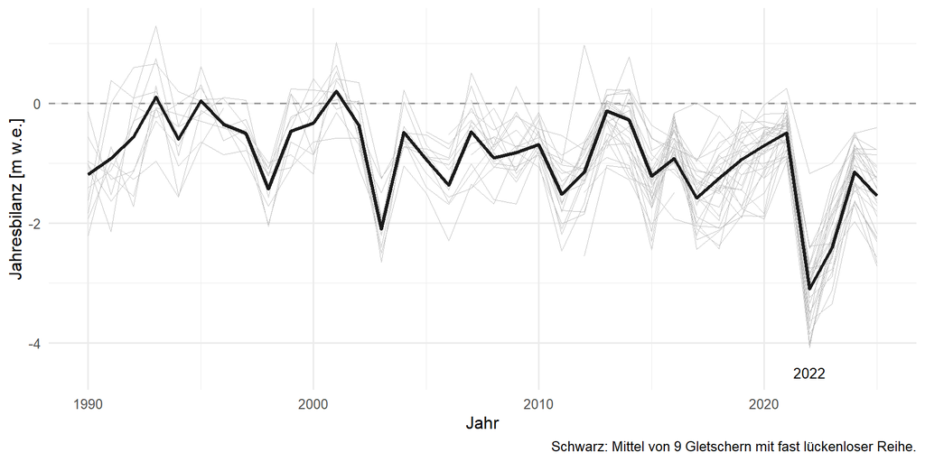

```r
gl |>
  filter(jahr >= 1990) |>
  ggplot(aes(jahr, Ba_m)) +
  geom_hline(yintercept = 0, linetype = "dashed", colour = "grey60") +
  geom_line(aes(group = glacier_id), colour = "grey75", linewidth = 0.3) +
  geom_line(data = reihe_konstant, aes(y = Ba), colour = "grey10", linewidth = 1.2) +
  annotate("text", x = 2022, y = -4.5, label = "2022", size = 3.5) +
  labs(x = "Jahr", y = "Jahresbilanz [m w.e.]",
       caption = paste0("Schwarz: Mittel von ", nrow(konstant),
                        " Gletschern mit fast lückenloser Reihe."))
```

**Erkenntnis:** In den 36 Jahren seit 1990 ist das Mittel nur in drei Jahren (darunter 1993 und 2001) knapp positiv.Besonders auffällig ist das Jahr 2022, welches ein sehr negatives Resultat aufweist.

### 2.8.3 Ansatz 3: Winter- und Sommerbilanz getrennt

**Frage:** Entsteht der Massenverlust durch weniger Schnee im Winter oder durch mehr Schmelze im Sommer?

**Aufbau der Visualisierung** Balken vom Nullpunkt aus. Die Winterbilanz (Akkumulation) zeigt nach oben, die Sommerbilanz (Massenverlust) nach unten, jeweils auf derselben y-Skala. Die schwarze Linie ist die Jahresbilanz, die Summe der beiden. Alle drei Werte stammen vom konstanten Sample aus Ansatz 2. Die Werte sind so direkt Verlgeichbar.

**Code anzeigen**

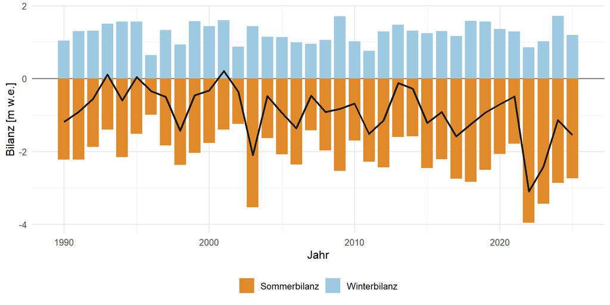

Abbildung 5: Ansatz 3: Winterbilanz (oben), Sommerbilanz (unten) und Jahresbilanz (Linie), Mittel des konstanten Samples

```r
reihe_konstant |>
  pivot_longer(c(Bw, Bs), names_to = "saison", values_to = "wert") |>
  mutate(saison = recode(saison, Bw = "Winterbilanz", Bs = "Sommerbilanz")) |>
  ggplot(aes(jahr, wert)) +
  geom_hline(yintercept = 0, colour = "grey50") +
  geom_col(aes(fill = saison), width = 0.8) +
  geom_line(data = reihe_konstant, aes(y = Ba), colour = "grey10", linewidth = 1) +
  scale_fill_manual(values = c(Winterbilanz = "#9ecae1", Sommerbilanz = "#e08a2c")) +
  labs(x = "Jahr", y = "Bilanz [m w.e.]", fill = NULL) +
  theme(legend.position = "bottom")
```

**Erkenntnis:** Die Aufteilung zeigt, dass die Winterbilanz im Mittel stabil blieb, während die Sommerbilanz negativer wird. Die Jahresbilanz folgt fast ausschliesslich der Sommerbilanz (Korrelation 0.92, mit der Winterbilanz nur 0.35). Auch das Jahr 2022 erklärt sich so: Die Schneemenge im Winter war mit 0.86 m w.e. unterdurchschnittlich, vor allem aber war die Sommerschmelze mit −4.0 m w.e. die höchste im Sample.

## 2.10 Peer-Feedback und nächste Iteration

**Hinweis**

Wird nach der Vorlesung mit dem Feedback der anderen Studierenden ergänzt.